# STAT216 Activity 45: Datasaurus Vex

## Synopsis

Congratulations on making it to the end of this course and the final activity! My hope is that this last activity is shorter, and possibly easier, than previous activities, while also illustrating a few key techniques and ideas. In particular, I hope this activity will:

- reinforce and strengthen your ability to make plots in `R` using `ggplot`.
- teach you how to perform basic linear regression in `R`.
- most importantly, remind you that the human element in interpreting statistics is as important, if not more so, than the quantitative side of the subject.

Thanks for a great semester! I hope you enjoyed it and hope you enjoy this final activity.

## Getting started

### Creating a reproducible lab report

We will again use R Markdown to create a lab report. In RStudio, go to New File -> R Markdown. Then, choose “From Template” and select `Lab Report for OpenIntro Statistics Labs`.

For a bit of additional assistance, check out [this video created by OpenIntro](https://youtu.be/Pdc368lS2hk).

Note: For each exercise, you should have a subsection that begins with `### Exercise` followed by the exercise number and a completely blank like. As an example,

```
[End of Exercise 1 work.]

### Exercise 2

[Your work here.]
```

### Loading packages and data

We’ll use the `tidyverse` and `openintro` packages in this lab, so let’s first load these packages from the console. Be sure to also include these packages in the beginning of your lab notebook.

We will get our data for this lab from an `R` package called `datasauRus`. You will need to install this package first, then load it at the beginning of your lab notebook.

Once you’ve loaded the new package, we want to use the `datasaurus_dozen` data set from it. We will call this data set `df`.

The first code chunk in your report will look something like this:

```r
library(knitr)
library(tidyverse)
library(openintro)
library(datasauRus)
#copying datasaurus_dozen
df <- datasaurus_dozen
head(df)
```

```
## # A tibble: 6 x 3
##   dataset     x     y
##   <chr>   <dbl> <dbl>
## 1 dino     55.4  97.2
## 2 dino     51.5  96.0
## 3 dino     46.2  94.5
## 4 dino     42.8  91.4
## 5 dino     40.8  88.3
## 6 dino     38.7  84.9
```

The data set we’re using today was created by Justin Matejka and George Fitzmaurice (based on a Tweet from Alberto Cairo) as a modern take on the famous Anscombe’s quartet.The data is entirely simulated and has no “real world” implications, aside from the data anaylsis lessons we’ll learn today.

The end of this activity will provide some links to describe how they created the data set and their motivation for doing so.

```r
sort(unique(df$dataset))
```

```
##  [1] "away"       "bullseye"   "circle"     "dino"       "dots"
##  [6] "h_lines"    "high_lines" "slant_down" "slant_up"   "star"
## [11] "v_lines"    "wide_lines" "x_shape"
```

Each set consists of 2 numerical variables simply called $x$ and $y$. They don’t have any physical meaning, but we’ll think of $x$ as the explanatory variable and $y$ as the response.

1. First, we want to look at the `v_lines` data set in `df`.
   - Subset/filter `df` to select only the `v_lines` data and assign the result to a data frame called `v_lines`.
   - What are the average values of `x` and `y` in this data set?

## Linear regression and plotting

This document will analyze the `slant_down` subset of `df`; you will continue to analyze `v_lines`.

```r
slant_down <- df %>% filter(dataset == "slant_down")
```

First things first, we want to compute a linear regression model for the relationship between $x$ and $y$.

```r
m1 <- lm(y ~ x, data= slant_down)
m1
```

```
##
## Call:
## lm(formula = y ~ x, data = slant_down)
##
## Coefficients:
## (Intercept)            x
##     53.8497      -0.1108
```

How should we interpret these results? The `(Intercept)` is the $y$-intercept and the `x` coefficient is the slope, so our linear model is
$$y = 53.8497 -0.1108\cdot x$$

This is great, but we don’t have much of an indication of how strong the linear relationship between $x$ and $y$ is. Fortunately, `R` has secretly made a lot of calculations for us beneath the hood. We need to know what to ask for and how to interpret it.

```r
m1summary <- summary(m1)
m1summary
```

```
##
## Call:
## lm(formula = y ~ x, data = slant_down)
##
## Residuals:
##     Min      1Q  Median      3Q     Max
## -47.855 -20.283  -1.849  20.947  51.612
##
## Coefficients:
##             Estimate Std. Error t value Pr(>|t|)
## (Intercept)  53.8497     7.6912   7.001 9.69e-11 ***
## x            -0.1108     0.1355  -0.818    0.415
## ---
## Signif. codes:  0 '***' 0.001 '**' 0.01 '*' 0.05 '.' 0.1 ' ' 1
##
## Residual standard error: 26.97 on 140 degrees of freedom
## Multiple R-squared:  0.004758,   Adjusted R-squared:  -0.002351
## F-statistic: 0.6693 on 1 and 140 DF,  p-value: 0.4147
```

There’s a lot to take in here. One of the first things we notice is that $R^2 \approx 0.00476$, so our linear relationship isn’t very strong. In particular, variation in $x$ doesn’t explain much of the variability in $y$. This is further reinforced when we look at the correlation coefficient $R$:

```r
cor(slant_down$x, slant_down$y)
```

```
## [1] -0.06897974
```

2. Create a linear model for the association between $x$ and $y$ in your `v_lines` data set.
   - What are the slope and $y$-intercept. Interpret the slope.
   - What is $R^2$ of your model? Interpret this value.
   - Do you think a linear model is appropriate for the `v_lines` data set?

Since the correlation coefficient is low, maybe we should check the residuals. Recall that a condition for fitting a least squares line to data is the residuals are approximately normally distributed. We will check these heuristically. The code below finds the average residual, the standard deviation of the residuals, then finds the Z-score of the minimum and maximum residuals.

```r
resMean <- mean(m1$residuals)
resS <- sd(m1$residuals)
resExt <- c( min(m1$residuals), max(m1$residuals))
resZ <- (resExt - resMean)/resS
resMean
```

```
## [1] -3.350997e-15
```

```r
resZ
```

```
## [1] -1.780854  1.920659
```

So there are no extreme residuals and the average residual is close to 0 - this is reasonable evidence that we are not violating the normality condition.

3. Does the `v_lines` data set seem to violate the normality condition? Explain your answer.

Maybe we should have actually **looked** at the data more carefully before performing all of these calculations. Let’s do so now.

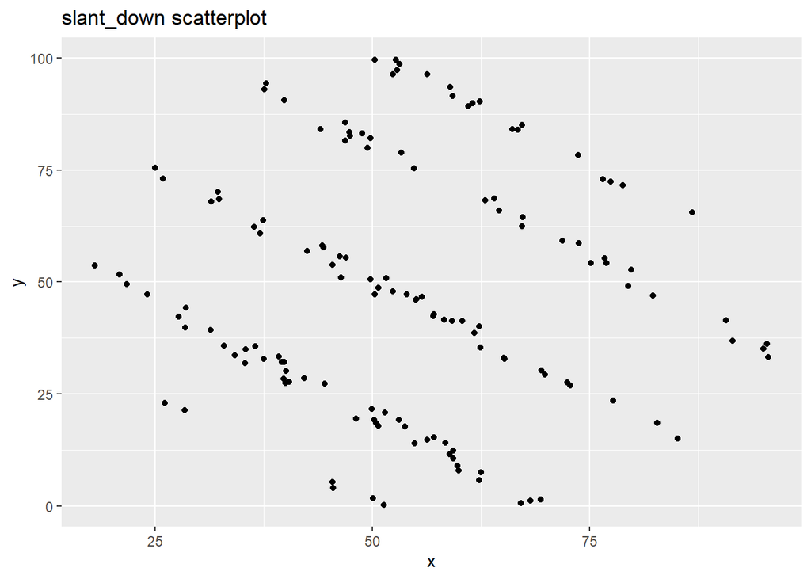

```r
ggplot(slant_down, aes(x = x, y = y)) +
  geom_point() +
  labs(title = "slant_down scatterplot")
```

Ah ha! We have 5 different clusters of data that seem to be following an approximately linear trend. While we could do some analysis to ID these clusters, we’ll leave that for a later course. This explains, at least partially, why the $R^2$-value of the association in $slant_down$ is so low.

`R` makes it quite easy to plot the line generated by a linear model. We want to add a new layer to our previous plot, using `geom_smooth` as follows.

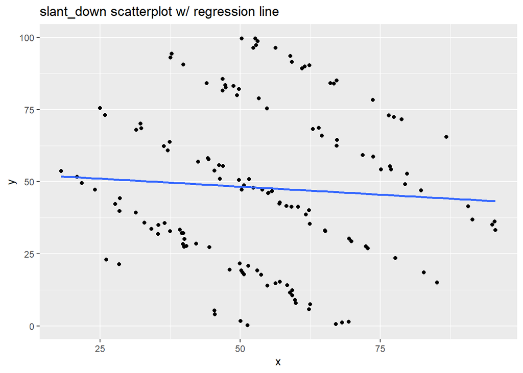

```r
ggplot(slant_down, aes(x = x, y = y)) +
  geom_point() +
  geom_smooth(method = 'lm', se = FALSE)+
  labs(title = "slant_down scatterplot w/ regression line")
```

From the plot above, we see that the linear model `m1` isn’t sophisticated enough to detect the clustering and different linear associations present “confuse” our model.

4. Create a scatter plot with the regression line for the `v_lines` data set. Describe any patterns you see in the data. Does a linear model seem any more or less appropriate?